# Factors that affect student exam scores

## by Khaya Monica Moyana

## Investigation Overview

I will be investigating different factors that affect student exam scores. These factors are race, gender, lunch, parental level of education and test preparation course.

## Dataset Overview

This dataset is found on [Kaggle](https://www.kaggle.com/datasets/spscientist/students-performance-in-exams). It includes scores from three exams and a variety of personal, social, and economic factors that have interaction effects upon them. It is made up of 1000 rows and 8 columns

## Performance of students by gender

The students were grouped into males and females. The graph shows that there isn't a significant difference between the performance of males and females.The upper quartile, median and lower quartile are almost the same for both male and female

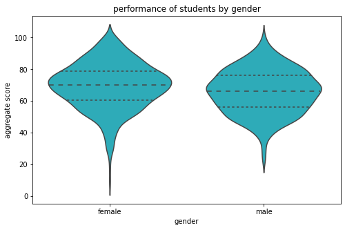

## Effects of taking lunch befere the exam

There are two categeries for lunch, standard lunch and free/reduced lunch. Sudents who took standard lunch otained higher aggregate scores than those who took low quality lunch

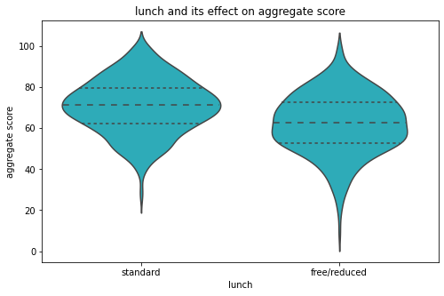

## Effects of taking the test preparation course

The are two categories for this which is those who completed the preparation course and those who did not. students who took the preparation course did exceptionally well on their exams. their aggregate scores bulge and widens mostly at 70 to 80

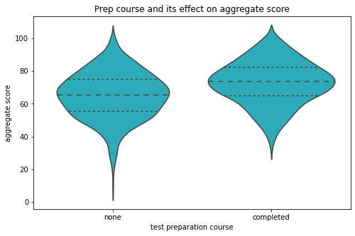

## Change in aggregate score as a factor of lunch and test preparation course

It is clear that in both learners who took s the preparation course and those that didn't, those who ate standard lunch performed better. But also, taking standard lunch and a preperation course had an overall success rate in the exams

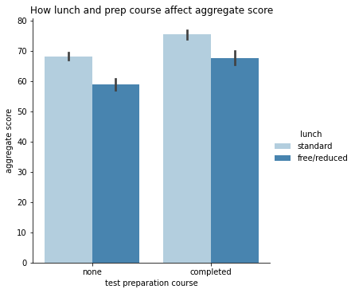